# TORNADO plot in R (updated)

Author

Maxime Fleury - Paoli-Calmettes Institut

Published

October 5, 2026

**📌 About Us**

**Links**

[Maxime Fleury website](https://fleury21.github.io/data_scientist_page/my_page_CV.html)

**contact:** fleurym@ipc.unicancer.fr

**License**

Clinical Graphics by Maxime FLEURY is licensed under CC BY-NC-SA 4.0

[figure not shown]

**Community**

[Innostatclinical](https://innostatclinical.com/en/)

**Contributor**

Maxime Fleury, *Author, maintainer* - Health Statistician

**Dev status**

*Vignette creation:* 05/10/2026

*Last update:* 05/10/2026

*Repos status:* Active

# Objectives

This article is a follow-up to the **Clinical Graphics page** dedicated to *Tornado plots*. Its purpose is to provide additional insights for **R tornado plot**.

For a comprehensive overview of the **theoretical principles underlying Tornado plots**, readers are encouraged to consult the [my Tornado plot page](https://fleury21.github.io/clinical_graphics_gallery/Tornado_plot_page.html).

# Tornado plot in R

The R pipeline enables the creation and customization of Tornado Plots from ADSL and ADAE datasets that comply with CDISC ADaM standards.

More specifically, the tool developed at UBM provides the following features:

- **Inclusion or exclusion** of ungraded adverse events
- **Stratification** of adverse event summaries according to a selected toxicity grade
- **Customization** of result rounding
- Customization of colors, axis labels, and legend labels
- **Configuration** of PNG output settings, including image dimensions and resolution
- **Filtering of System Organ Classes (SOCs)** based on specific labels or grades

This flexibility allows users to easily adapt the generated graphics to the requirements of a clinical study protocol, a statistical report, or a scientific publication.

Examples of outputs generated using this pipeline are shown below.

**By arm with stratification (grade >=3)**

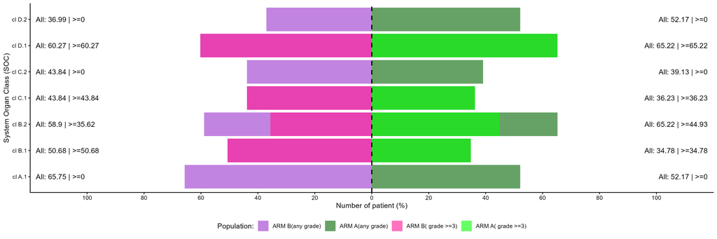

**By arm only**

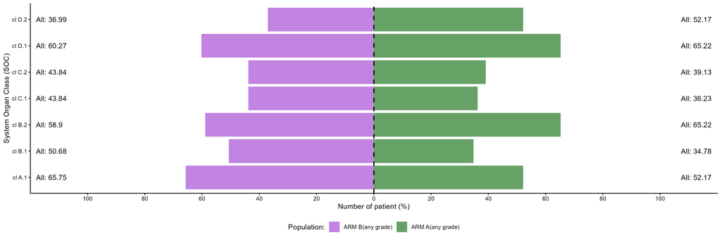

**Overall population with stratification (grade >=3)**

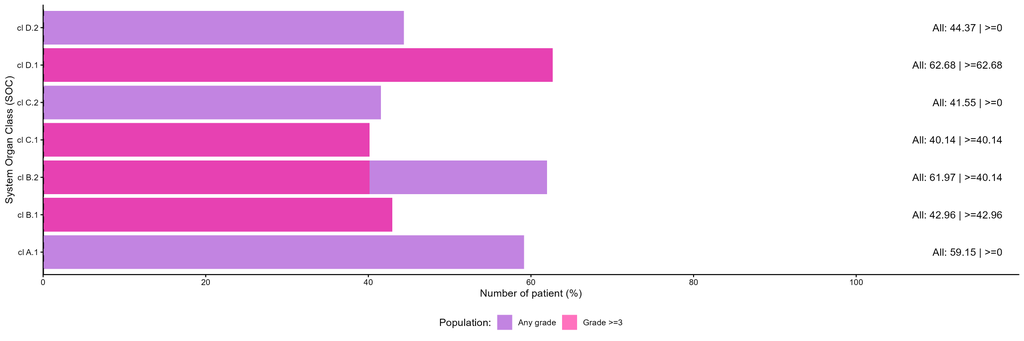

**Overall population only**

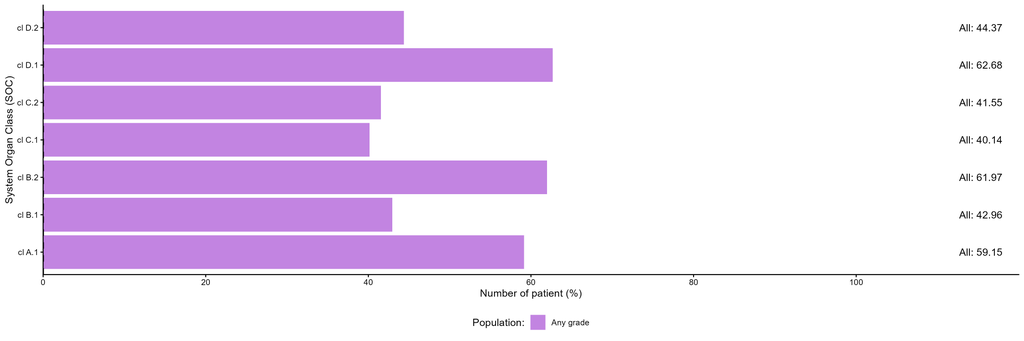

Given the growing use of publicly available source code for training artificial intelligence models, the **R code underlying this pipeline will not be publicly disclosed on this website**.

The purpose of this vignette is to present the pipeline’s features, customization options, and generated outputs without providing details of its underlying implementation.

For further information, demonstration requests, or collaboration opportunities, please visit the Contact page at: [InnoStatClinical](https://innostatclinical.com/en/contact/).